# Recell_Project_v2

```python
# this will help in making the Python code more structured automatically (good coding practice)
%load_ext nb_black

# Libraries to help with reading and manipulating data
import numpy as np
import pandas as pd

# Libraries to help with data visualization
import matplotlib.pyplot as plt
import seaborn as sns

sns.set()

# to split the data into train and test
from sklearn.model_selection import train_test_split

# to build linear regression_model
from sklearn.linear_model import LinearRegression

# to check model performance
from sklearn.metrics import mean_absolute_error, mean_squared_error, r2_score

# to build linear regression_model using statsmodels
import statsmodels.api as sm
```

```
The nb_black extension is already loaded. To reload it, use:
  %reload_ext nb_black
```

```python
# loading the dataset
data = pd.read_csv("used_phone_data.csv")
```

### Data Overview

```python
data.head()
```

|  | brand_name | os | screen_size | 4g | 5g | main_camera_mp | selfie_camera_mp | int_memory | ram | battery | weight | release_year | days_used | new_price | used_price |
| --- | --- | --- | --- | --- | --- | --- | --- | --- | --- | --- | --- | --- | --- | --- | --- |
| 0 | Honor | Android | 23.97 | yes | no | 13.0 | 5.0 | 64.0 | 3.0 | 3020.0 | 146.0 | 2020 | 127 | 111.62 | 86.96 |
| 1 | Honor | Android | 28.10 | yes | yes | 13.0 | 16.0 | 128.0 | 8.0 | 4300.0 | 213.0 | 2020 | 325 | 249.39 | 161.49 |
| 2 | Honor | Android | 24.29 | yes | yes | 13.0 | 8.0 | 128.0 | 8.0 | 4200.0 | 213.0 | 2020 | 162 | 359.47 | 268.55 |
| 3 | Honor | Android | 26.04 | yes | yes | 13.0 | 8.0 | 64.0 | 6.0 | 7250.0 | 480.0 | 2020 | 345 | 278.93 | 180.23 |
| 4 | Honor | Android | 15.72 | yes | no | 13.0 | 8.0 | 64.0 | 3.0 | 5000.0 | 185.0 | 2020 | 293 | 140.87 | 103.80 |

```python
# check number of rows and columns
data.shape
```

```
(3571, 15)
```

```python
# checking column datatypes and number of non-null values
data.info()
```

```
<class 'pandas.core.frame.DataFrame'>
RangeIndex: 3571 entries, 0 to 3570
Data columns (total 15 columns):
 #   Column            Non-Null Count  Dtype
---  ------            --------------  -----
 0   brand_name        3571 non-null   object
 1   os                3571 non-null   object
 2   screen_size       3571 non-null   float64
 3   4g                3571 non-null   object
 4   5g                3571 non-null   object
 5   main_camera_mp    3391 non-null   float64
 6   selfie_camera_mp  3569 non-null   float64
 7   int_memory        3561 non-null   float64
 8   ram               3561 non-null   float64
 9   battery           3565 non-null   float64
 10  weight            3564 non-null   float64
 11  release_year      3571 non-null   int64
 12  days_used         3571 non-null   int64
 13  new_price         3571 non-null   float64
 14  used_price        3571 non-null   float64
dtypes: float64(9), int64(2), object(4)
memory usage: 418.6+ KB
```

```python
# let's create a copy of the data to avoid any changes to original data
df = data.copy()
```

```python
# check for null values in the dataset
df.isnull().sum()
```

```
brand_name            0
os                    0
screen_size           0
4g                    0
5g                    0
main_camera_mp      180
selfie_camera_mp      2
int_memory           10
ram                  10
battery               6
weight                7
release_year          0
days_used             0
new_price             0
used_price            0
dtype: int64
```

- observation
1. There are null values in main_camera_mp,selfie_camera_mp,int_memory,ram,battery and weigh

```python
# Let's look at the statistical summary of the data
data.describe(include="all").T
```

|  | count | unique | top | freq | mean | std | min | 25% | 50% | 75% | max |
| --- | --- | --- | --- | --- | --- | --- | --- | --- | --- | --- | --- |
| brand_name | 3571 | 34 | Others | 509 | NaN | NaN | NaN | NaN | NaN | NaN | NaN |
| os | 3571 | 4 | Android | 3246 | NaN | NaN | NaN | NaN | NaN | NaN | NaN |
| screen_size | 3571 | NaN | NaN | NaN | 14.8039 | 5.15309 | 2.7 | 12.7 | 13.49 | 16.51 | 46.36 |
| 4g | 3571 | 2 | yes | 2359 | NaN | NaN | NaN | NaN | NaN | NaN | NaN |
| 5g | 3571 | 2 | no | 3419 | NaN | NaN | NaN | NaN | NaN | NaN | NaN |
| main_camera_mp | 3391 | NaN | NaN | NaN | 9.40045 | 4.8184 | 0.08 | 5 | 8 | 13 | 48 |
| selfie_camera_mp | 3569 | NaN | NaN | NaN | 6.54735 | 6.87936 | 0.3 | 2 | 5 | 8 | 32 |
| int_memory | 3561 | NaN | NaN | NaN | 54.5326 | 84.6962 | 0.005 | 16 | 32 | 64 | 1024 |
| ram | 3561 | NaN | NaN | NaN | 4.05696 | 1.39184 | 0.03 | 4 | 4 | 4 | 16 |
| battery | 3565 | NaN | NaN | NaN | 3067.23 | 1364.21 | 80 | 2100 | 3000 | 4000 | 12000 |
| weight | 3564 | NaN | NaN | NaN | 179.424 | 90.2809 | 23 | 140 | 159 | 184 | 950 |
| release_year | 3571 | NaN | NaN | NaN | 2015.96 | 2.29178 | 2013 | 2014 | 2016 | 2018 | 2020 |
| days_used | 3571 | NaN | NaN | NaN | 675.391 | 248.641 | 91 | 536 | 690 | 872 | 1094 |
| new_price | 3571 | NaN | NaN | NaN | 237.389 | 197.546 | 9.13 | 120.13 | 189.8 | 291.935 | 2560.2 |
| used_price | 3571 | NaN | NaN | NaN | 109.88 | 121.501 | 2.51 | 45.205 | 75.53 | 126 | 1916.54 |

- Observation
1. The mean used price of the phone is 109.88 euros. There seems to be huge variances in the min and max prices of the used phones. Min price is 2.51 euros whereas maximum price is 1916.54 euros

```python
# check the number of unique values in each column of the dataframe
data.nunique()
```

```
brand_name            34
os                     4
screen_size          127
4g                     2
5g                     2
main_camera_mp        44
selfie_camera_mp      37
int_memory            16
ram                   14
battery              354
weight               613
release_year           8
days_used            930
new_price           3099
used_price          3044
dtype: int64
```

```python
# print the unique values from certain columns to get an understanding of brand names,os and release years
col_list = ["brand_name", "os", "release_year"]
for i in col_list:
    print(data[i].unique())
```

```
['Honor' 'Others' 'HTC' 'Huawei' 'Infinix' 'Lava' 'Lenovo' 'LG' 'Meizu'
 'Micromax' 'Motorola' 'Nokia' 'OnePlus' 'Oppo' 'Realme' 'Samsung' 'Vivo'
 'Xiaomi' 'ZTE' 'Apple' 'Asus' 'Coolpad' 'Acer' 'Alcatel' 'BlackBerry'
 'Celkon' 'Gionee' 'Google' 'Karbonn' 'Microsoft' 'Panasonic' 'Sony'
 'Spice' 'XOLO']
['Android' 'Others' 'iOS' 'Windows']
[2020 2019 2013 2014 2016 2018 2015 2017]
```

- Observation
1. Release years are from 2013 to 2020
2. The 4 unique OS are - Android,Others,iOS,Windows
3. There are totally 34 brands of phone that are in the used phone market

# EDA

## Univariate analysis

```python
# function to plot a boxplot and a histogram along the same scale.


def histogram_boxplot(data, feature, figsize=(12, 7), kde=False, bins=None):
    """
    Boxplot and histogram combined

    data: dataframe
    feature: dataframe column
    figsize: size of figure (default (12,7))
    kde: whether to the show density curve (default False)
    bins: number of bins for histogram (default None)
    """
    f2, (ax_box2, ax_hist2) = plt.subplots(
        nrows=2,  # Number of rows of the subplot grid= 2
        sharex=True,  # x-axis will be shared among all subplots
        gridspec_kw={"height_ratios": (0.25, 0.75)},
        figsize=figsize,
    )  # creating the 2 subplots
    sns.boxplot(
        data=data, x=feature, ax=ax_box2, showmeans=True, color="violet"
    )  # boxplot will be created and a star will indicate the mean value of the column
    sns.histplot(
        data=data, x=feature, kde=kde, ax=ax_hist2, bins=bins, palette="winter"
    ) if bins else sns.histplot(
        data=data, x=feature, kde=kde, ax=ax_hist2
    )  # For histogram
    ax_hist2.axvline(
        data[feature].mean(), color="green", linestyle="--"
    )  # Add mean to the histogram
    ax_hist2.axvline(
        data[feature].median(), color="black", linestyle="-"
    )  # Add median to the histogram
```

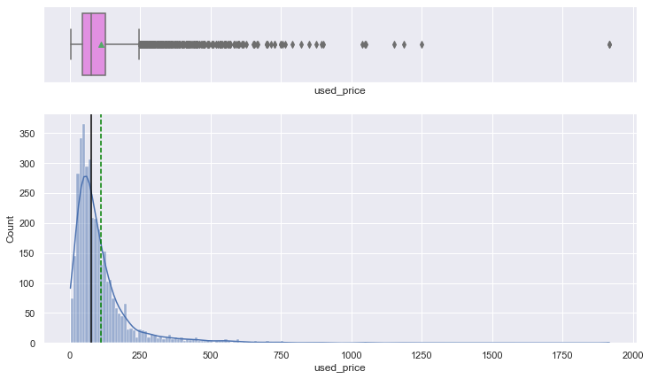

```python
histogram_boxplot(data, "used_price", kde=True)
```

- Observations
1. There are outliers in the used_price variable
2. It is right skewed

### let us explore os

```python
# function to create labeled barplots


def labeled_barplot(data, feature, perc=False, n=None):
    """
    Barplot with percentage at the top

    data: dataframe
    feature: dataframe column
    perc: whether to display percentages instead of count (default is False)
    n: displays the top n category levels (default is None, i.e., display all levels)
    """

    total = len(data[feature])  # length of the column
    count = data[feature].nunique()
    if n is None:
        plt.figure(figsize=(count + 1, 5))
    else:
        plt.figure(figsize=(n + 1, 5))

    plt.xticks(rotation=90, fontsize=15)
    ax = sns.countplot(
        data=data,
        x=feature,
        palette="Paired",
        order=data[feature].value_counts().index[:n].sort_values(),
    )

    for p in ax.patches:
        if perc == True:
            label = "{:.1f}%".format(
                100 * p.get_height() / total
            )  # percentage of each class of the category
        else:
            label = p.get_height()  # count of each level of the category

        x = p.get_x() + p.get_width() / 2  # width of the plot
        y = p.get_height()  # height of the plot

        ax.annotate(
            label,
            (x, y),
            ha="center",
            va="center",
            size=12,
            xytext=(0, 5),
            textcoords="offset points",
        )  # annotate the percentage

    plt.show()  # show the plot
```

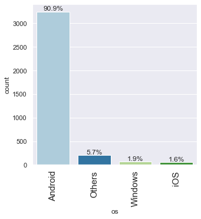

```python
labeled_barplot(data, "os", perc=True)
```

- Observations
1. Android has the highest percentage of 90.9 followed by other,windows and ios

### let us explore manufacturing brands

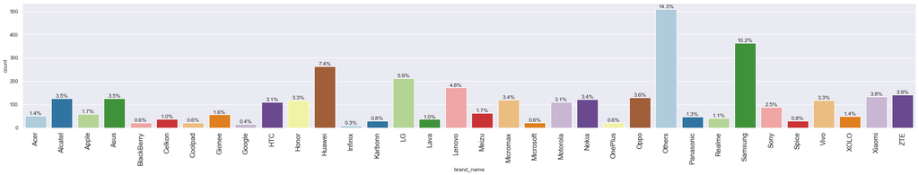

```python
labeled_barplot(data, "brand_name", perc=True)
```

```python
data["brand_name"].value_counts().sort_values(ascending=False)
```

```
Others        509
Samsung       364
Huawei        264
LG            212
Lenovo        172
ZTE           141
Xiaomi        134
Oppo          129
Asus          126
Alcatel       125
Nokia         121
Micromax      120
Honor         118
Vivo          117
Motorola      110
HTC           110
Sony           88
Meizu          62
Apple          59
Gionee         56
Acer           51
XOLO           49
Panasonic      47
Realme         41
Celkon         37
Lava           36
Spice          30
Karbonn        30
Coolpad        22
Microsoft      22
BlackBerry     22
OnePlus        22
Google         15
Infinix        10
Name: brand_name, dtype: int64
```

- observations
1. Others is the top manufacturing brand followed by Samsung and Huawei

```python
# creating a list of top 10 brands
top_brand_list = [
    "Alcatel",
    "Asus",
    "Oppo",
    "Xiaomi",
    "ZTE",
    "Lenovo",
    "LG",
    "Huawei",
    "Samsung",
    "Others",
]
top_brand_list
```

```
['Alcatel',
 'Asus',
 'Oppo',
 'Xiaomi',
 'ZTE',
 'Lenovo',
 'LG',
 'Huawei',
 'Samsung',
 'Others']
```

### let us explore screen size

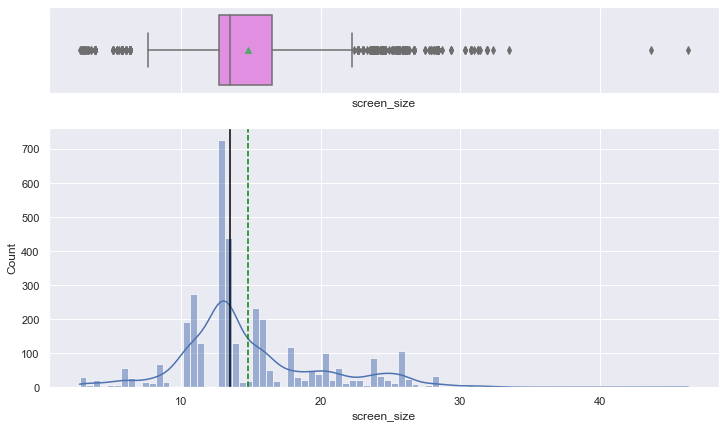

```python
histogram_boxplot(data, "screen_size", kde=True)
```

- Observations
1. There are outliers on the left and right hand of the box plot
2. The distribution seems to be slightly right skewed

### let us explore 4g and 5g

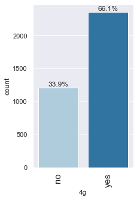

```python
labeled_barplot(data, "4g", perc=True)
```

- Observations
1. 66.1% have 4g connectivity in the dataset

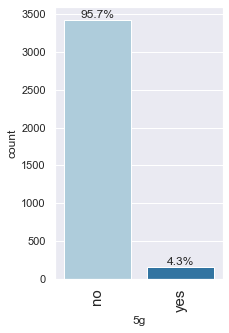

```python
labeled_barplot(data, "5g", perc=True)
```

- Observation1
1. Only 4.3% have 5g connectivity. Overall it looks like the 4g connectivity is more in numbers compared to 5g

### let us explore main_camera_mp and selfie_camera_mp

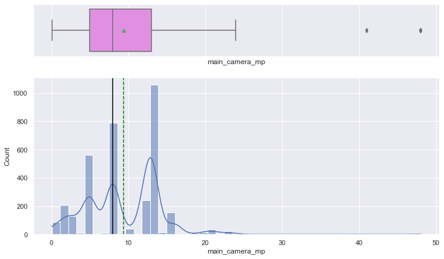

```python
histogram_boxplot(data, "main_camera_mp", kde=True)
```

- Observations
1. The mean size if mega pixels in the main camera is 9.4 mp. The distribution is skewed on both the sides. There are few outliers as well

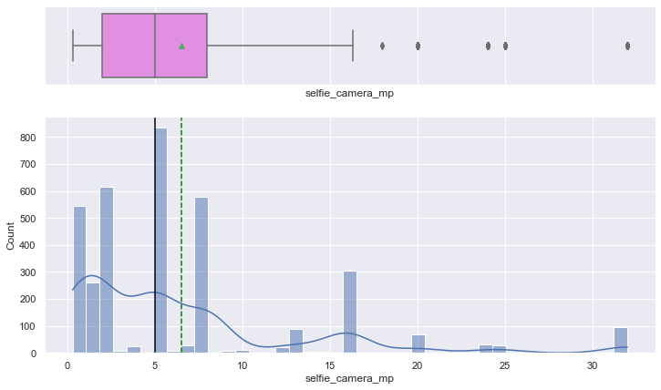

```python
histogram_boxplot(data, "selfie_camera_mp", kde=True)
```

- Observations
1. The mean size if mega pixels in the selfie camera is 6.5 mp. The distribution is skewed right side as it has a longer tail. There are few outliers as well

### let us explore internal memory

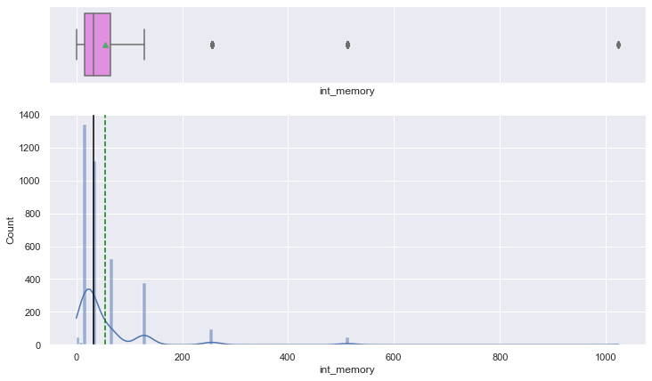

```python
histogram_boxplot(data, "int_memory", kde=True)
```

- Observation
1. The mean size of the internal memory is 54 GB. The distribution is right skewed.There are outliers in this variable

### let us explore RAM

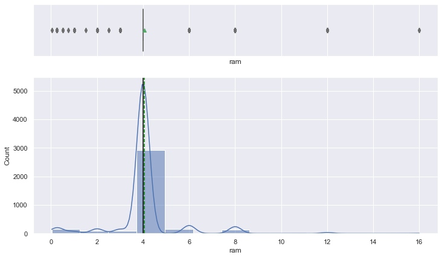

```python
histogram_boxplot(data, "ram", kde=True)
```

- Observations
1. The mean size of RAM is 4 GB. The distribution is skewed on both the sides and there are outliers in this variable

### let us explore battery

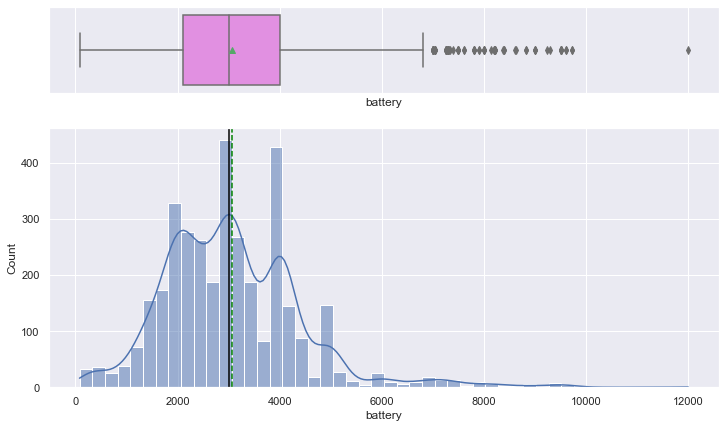

```python
histogram_boxplot(data, "battery", kde=True)
```

- Observations
1. The mean size of battery is 3067.23 mAh. The distribution is skewed on both the sides and there are outliers in this variable

### let us explore weight

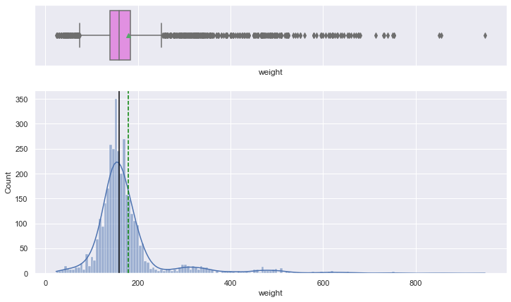

```python
histogram_boxplot(data, "weight", kde=True)
```

- Observations
1. The mean weight of the phone is 179.424 grams. The tail is longer on the right side and the distribution is right skewed. There are outliers in this variable

### let us explore release_year

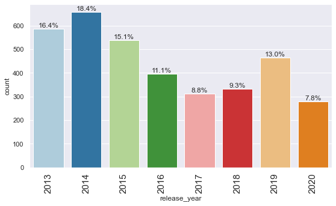

```python
labeled_barplot(data, "release_year", perc=True)
```

- Observations
1. The 2014 model releases year is dominating this market,followed by 2013 and then 2015.

### let us explore days_used

```python
# we might have to create bins so that it will help us visualize
daysuseddata = data.copy()
daysuseddata = daysuseddata.assign(
    days_used_group=pd.cut(
        data.days_used,
        bins=[90, 200, 600, 1000, np.inf],
        labels=["90-200", "200-600", "600-1000", "Above 1000"],
    )
)
daysuseddata.drop(["days_used"], axis=1, inplace=True)
daysuseddata.head(10)
```

|  | brand_name | os | screen_size | 4g | 5g | main_camera_mp | selfie_camera_mp | int_memory | ram | battery | weight | release_year | new_price | used_price | days_used_group |
| --- | --- | --- | --- | --- | --- | --- | --- | --- | --- | --- | --- | --- | --- | --- | --- |
| 0 | Honor | Android | 23.97 | yes | no | 13.0 | 5.0 | 64.0 | 3.0 | 3020.0 | 146.0 | 2020 | 111.62 | 86.96 | 90-200 |
| 1 | Honor | Android | 28.10 | yes | yes | 13.0 | 16.0 | 128.0 | 8.0 | 4300.0 | 213.0 | 2020 | 249.39 | 161.49 | 200-600 |
| 2 | Honor | Android | 24.29 | yes | yes | 13.0 | 8.0 | 128.0 | 8.0 | 4200.0 | 213.0 | 2020 | 359.47 | 268.55 | 90-200 |
| 3 | Honor | Android | 26.04 | yes | yes | 13.0 | 8.0 | 64.0 | 6.0 | 7250.0 | 480.0 | 2020 | 278.93 | 180.23 | 200-600 |
| 4 | Honor | Android | 15.72 | yes | no | 13.0 | 8.0 | 64.0 | 3.0 | 5000.0 | 185.0 | 2020 | 140.87 | 103.80 | 200-600 |
| 5 | Honor | Android | 21.43 | yes | no | 13.0 | 8.0 | 64.0 | 4.0 | 4000.0 | 176.0 | 2020 | 157.70 | 113.67 | 200-600 |
| 6 | Honor | Android | 19.84 | yes | no | 8.0 | 5.0 | 32.0 | 2.0 | 3020.0 | 144.0 | 2020 | 91.74 | 72.29 | 200-600 |
| 7 | Honor | Android | 18.57 | yes | no | 13.0 | 8.0 | 64.0 | 4.0 | 3400.0 | 164.0 | 2020 | 179.24 | 132.91 | 200-600 |
| 8 | Honor | Android | 15.72 | yes | no | 13.0 | 16.0 | 128.0 | 6.0 | 4000.0 | 165.0 | 2020 | 200.32 | 150.88 | 90-200 |
| 9 | Honor | Android | 21.43 | yes | no | 13.0 | 8.0 | 128.0 | 6.0 | 4000.0 | 176.0 | 2020 | 159.75 | 103.59 | 200-600 |

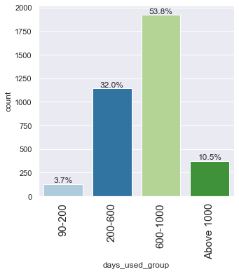

```python
labeled_barplot(daysuseddata, "days_used_group", perc=True)
```

- Observations
1. 53.8% of the used/refurbished phone has been used between 600-1000 days. This is followed by 32 % of phones that is used between 200-600 days

### let us explore new_price

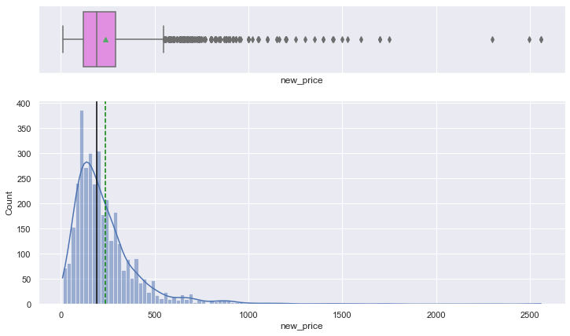

```python
histogram_boxplot(data, "new_price", kde=True)
```

- Observations
1. The right tail of the distribution is longer. There are outliers in this variable

## Bivariate Analysis

### Let's look at correlations.

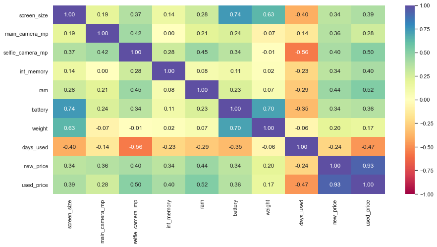

```python
numeric_columns = data.select_dtypes(include=np.number).columns.tolist()
numeric_columns.remove(
    "release_year"
)  # dropping year column as it is temporal variable

# correlation heatmap
plt.figure(figsize=(15, 7))
sns.heatmap(
    df[numeric_columns].corr(),
    annot=True,
    vmin=-1,
    vmax=1,
    fmt=".2f",
    cmap="Spectral",
)
plt.show()
```

- Observations
1. screen size is highly positively correlated with battery and weight
2. used price is highly positively correlated with new price
3. weight and battery is highly positively correlated with one and other

### Let's look at the graphs of a few variables that are highly correlated with used price.

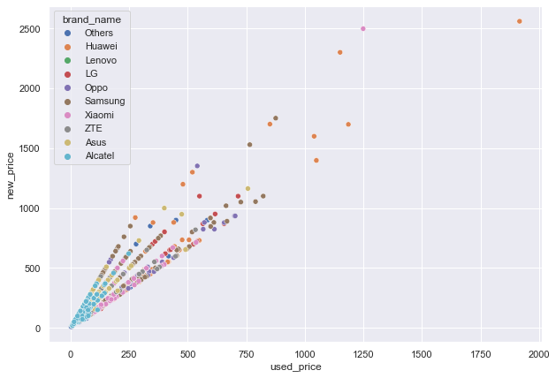

```python
# Abstracting the top 10 brands to visualize the correlation between used and new price
# Using scatterplot and heatmap to validate the details

data_tb = data.copy()
data_topbrands = pd.DataFrame({"brand_name": top_brand_list})
data_tb = df.merge(data_topbrands, on="brand_name")


plt.figure(figsize=(10, 7))
sns.scatterplot(y="new_price", x="used_price", hue="brand_name", data=data_tb)
plt.show()
```

- Observations
1. The relationship between used and new price shows an uphill pattern as we move from left to right indicating a positive relationship.

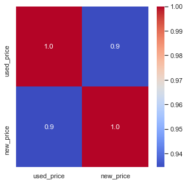

```python
num_var = ["used_price", "new_price"]
corr = data_tb[num_var].corr()

# plot the heatmap
plt.figure(figsize=(5, 5))
sns.heatmap(
    corr,
    annot=True,
    cmap="coolwarm",
    fmt=".1f",
    xticklabels=corr.columns,
    yticklabels=corr.columns,
)
```

- Observations
1. The heatmap for the top 10 brands also show a positive correlation between the used and new price

### let us explore weight with used price

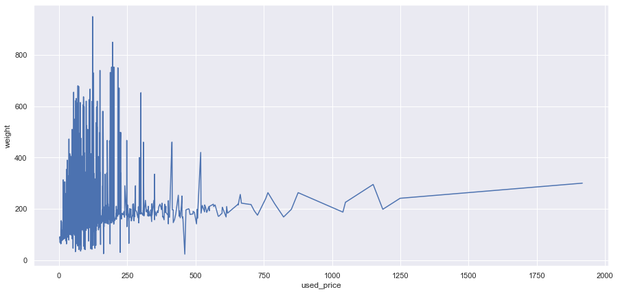

```python
# Here again we are analyzing for the top 10 brands

plt.figure(figsize=(15, 7))
sns.lineplot(x="used_price", y="weight", data=data_tb, ci=None)
# sns.lineplot(x="used_price", y="weight", data=data, ci=None) # analyzing it for the entire dataset
plt.show()
```

### let us explore battery with used price

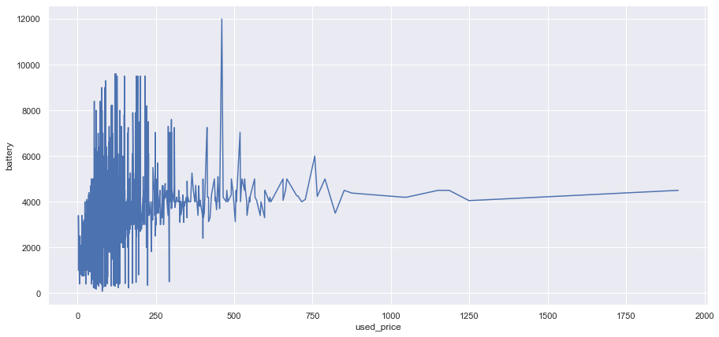

```python
plt.figure(figsize=(15, 7))
sns.lineplot(x="used_price", y="battery", data=data_tb, ci=None)
# sns.lineplot(x="used_price", y="battery", data=data, ci=None) # analyzing it for the entire dataset
plt.show()
```

### Data Preprocessing

#### Here we will check for the missing values and treat them

#### Once the above step is done,we will check the distribution of the variables and do preprocessing as required

```python
# counting the number of missing values per row
data.isnull().sum(axis=1).value_counts()
```

```
0    3368
1     193
2       8
3       2
dtype: int64
```

```python
# Check for missing values
data.isnull().sum()
```

```
brand_name            0
os                    0
screen_size           0
4g                    0
5g                    0
main_camera_mp      180
selfie_camera_mp      2
int_memory           10
ram                  10
battery               6
weight                7
release_year          0
days_used             0
new_price             0
used_price            0
dtype: int64
```

- Observations
1. There are missing values in main_camera_mp,selfie_camera_mp,int_memory,ram,battery and weight
2. Mean imputation seems to be best treatment for these variables. Will perform a quick check on this before incorporating it

```python
# perform a mean imputation and check for missing values in a temporary dataframe
data1 = data.copy()
data1["main_camera_mp"].fillna(
    data1["main_camera_mp"].mean(), inplace=True
)  # mean imputation
data1["selfie_camera_mp"].fillna(
    data1["selfie_camera_mp"].mean(), inplace=True
)  # mean imputation
data1["int_memory"].fillna(data1["int_memory"].mean(), inplace=True)  # mean imputation
data1["ram"].fillna(data1["ram"].mean(), inplace=True)  # mean imputation
data1["battery"].fillna(data1["battery"].mean(), inplace=True)  # mean imputation
data1["weight"].fillna(data1["weight"].mean(), inplace=True)  # mean imputation
data1.isnull().sum()
```

```
brand_name          0
os                  0
screen_size         0
4g                  0
5g                  0
main_camera_mp      0
selfie_camera_mp    0
int_memory          0
ram                 0
battery             0
weight              0
release_year        0
days_used           0
new_price           0
used_price          0
dtype: int64
```

```python
# Mean imputation treatment for missing values
data["main_camera_mp"].fillna(
    data["main_camera_mp"].mean(), inplace=True
)  # mean imputation
data["selfie_camera_mp"].fillna(
    data["selfie_camera_mp"].mean(), inplace=True
)  # mean imputation
data["int_memory"].fillna(data["int_memory"].mean(), inplace=True)  # mean imputation
data["ram"].fillna(data["ram"].mean(), inplace=True)  # mean imputation
# data["battery"].fillna(data["battery"].mean(), inplace=True)  # mean imputation
# data["weight"].fillna(data["weight"].mean(), inplace=True)  # mean imputation
data.isnull().sum()
```

```
brand_name          0
os                  0
screen_size         0
4g                  0
5g                  0
main_camera_mp      0
selfie_camera_mp    0
int_memory          0
ram                 0
battery             6
weight              7
release_year        0
days_used           0
new_price           0
used_price          0
dtype: int64
```

```python
data = data.drop(
    "release_year", axis=1
)  # dropping release_year column as it is temporal variable
```

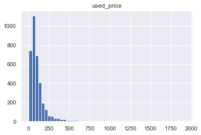

```
0
```

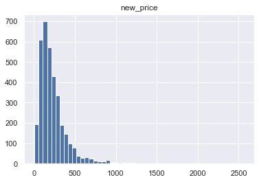

```
0
```

```python
# let us check the distribution of the used_price and new_price
cols_to_log = ["used_price", "new_price"]
for colname in cols_to_log:
    plt.hist(data[colname], bins=50)
    plt.title(colname)
    plt.show()
    print(np.sum(df[colname] <= 0))
```

- Observation
1. Since the data is skewed,let us apply the log,arcsinh and sqrt to see which best gives us a closer to normal distribution

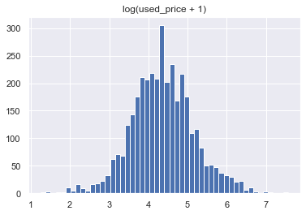

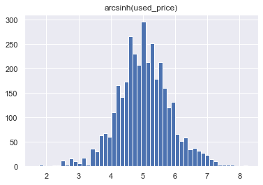

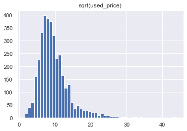

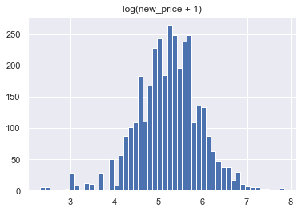

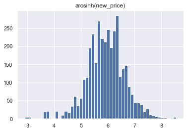

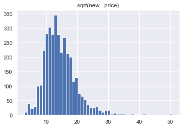

```python
plt.hist(np.log(data["used_price"] + 1), 50)
plt.title("log(used_price + 1)")
plt.show()
plt.hist(np.arcsinh(data["used_price"]), 50)
plt.title("arcsinh(used_price)")
plt.show()
plt.hist(np.sqrt(df["used_price"]), 50)
plt.title("sqrt(used_price)")
plt.show()

plt.hist(np.log(data["new_price"] + 1), 50)
plt.title("log(new_price + 1)")
plt.show()
plt.hist(np.arcsinh(data["new_price"]), 50)
plt.title("arcsinh(new_price)")
plt.show()
plt.hist(np.sqrt(df["new_price"]), 50)
plt.title("sqrt(new _price)")
plt.show()
```

- Observation
1. Based off the above,I will go with a log transformation and replace this in the dataframe

```python
# replace it in the dataframe
for colname in [cols_to_log]:
    data[colname] = np.log(data[colname] + 1)
# df.drop(cols_to_log, axis=1, inplace=True)
```